# Spatial data manipulation in R

### Reading Spatial Data

```r
#Download and install package
#install.packages("sf")
```

```r
#Load package
library(sf)
library(sp)
setwd("E:/Dropbox (Personal)/Auckland/Teaching/sem 1 2022/771/Lab 1/2024")


# Read Shapefile - there are three ways  for loading it :) you can choose which ever one you like.

SF = st_read("E:/Dropbox (Personal)/Auckland/Teaching/sem 1 2022/771/Lab 1/2024/data", layer = "tl_2010_06075_tract10")
SF = st_read("./data", layer = "tl_2010_06075_tract10")
SF = st_read("./data/tl_2010_06075_tract10.shp")
```

This has created a simple feature object/collection.

Please take some time to read these materials to get familiar with the concept: https://r-spatial.github.io/sf/articles/sf1.html

Sometimes we need to work with Spatial Data Frames and these can be obtained by by using a command:

```r
SF_1<-as(SF, "Spatial") #this turns simple feature to spatial data frame

SF_2<-st_as_sf(SF_1) #this turns spatial data frame to simple feature
```

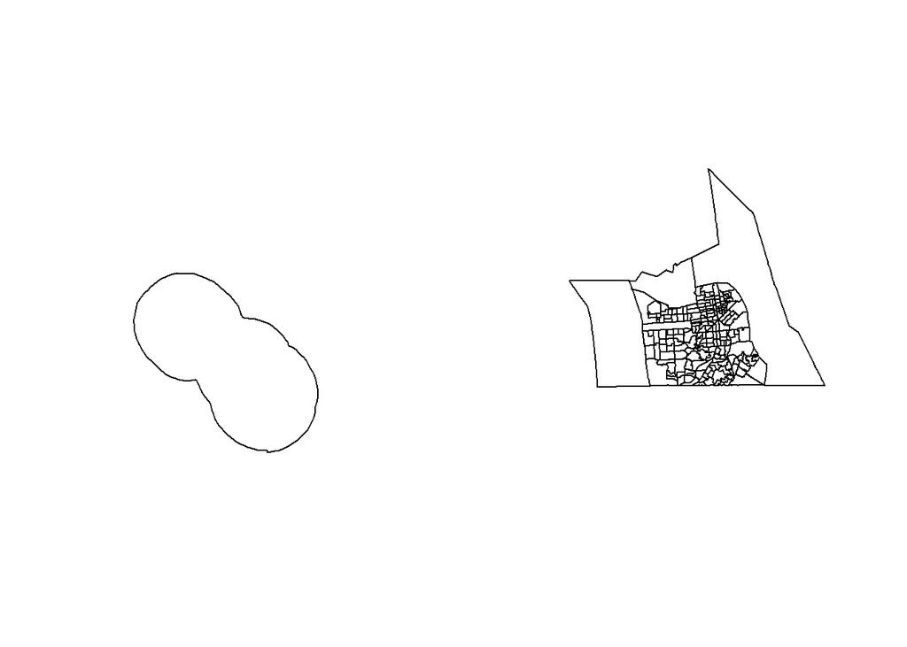

```r
#to have a look at how the data looks like use plot(). As we are using sf objects we need to specify st_geoemtry as well. You can have a look what happens if you dont add st_geometry to your plotting.
plot(st_geometry(SF))
```

The San Francisco peninsula is shown, however, the formal boundaries extend into the ocean and also include the Farallon Islands. For cartographic purposes it may not be desirable to show these extents, and later we will explore how these can be cleaned up.

A SpatialPolygonsDataFrame is an object that contains a series of ‘slots’ holding different items of data:

```r
#. The slotNames() function prints their names.
slotNames(SF_1)
```

```
## [1] "data"        "polygons"    "plotOrder"   "bbox"        "proj4string"
```

The objects stored within the slots can be accessed using the “@” symbol:

```r
#Show the top rows of the data object
head(SF_1@data$MTFCC10) #this is in the spatial data frame
```

```
## [1] "G5020" "G5020" "G5020" "G5020" "G5020" "G5020"
```

```r
head(SF_1@data)
```

```
##   STATEFP10 COUNTYFP10 TRACTCE10     GEOID10 NAME10       NAMELSAD10 MTFCC10
## 1        06        075    016500 06075016500    165 Census Tract 165   G5020
## 2        06        075    016400 06075016400    164 Census Tract 164   G5020
## 3        06        075    016300 06075016300    163 Census Tract 163   G5020
## 4        06        075    016100 06075016100    161 Census Tract 161   G5020
## 5        06        075    016000 06075016000    160 Census Tract 160   G5020
## 6        06        075    015900 06075015900    159 Census Tract 159   G5020
##   FUNCSTAT10 ALAND10 AWATER10  INTPTLAT10   INTPTLON10
## 1          S  370459        0 +37.7741958 -122.4477884
## 2          S  309097        0 +37.7750995 -122.4369729
## 3          S  245867        0 +37.7760456 -122.4295509
## 4          S  368901        0 +37.7799831 -122.4286631
## 5          S  158236        0 +37.7823363 -122.4224838
## 6          S  295388        0 +37.7833400 -122.4293428
```

```r
head(SF) # look what you can see if it is a simple feature
```

```
## Simple feature collection with 6 features and 12 fields
## Geometry type: POLYGON
## Dimension:     XY
## Bounding box:  xmin: -122.4547 ymin: 37.77193 xmax: -122.4202 ymax: 37.78544
## Geodetic CRS:  NAD83
##   STATEFP10 COUNTYFP10 TRACTCE10     GEOID10 NAME10       NAMELSAD10 MTFCC10
## 1        06        075    016500 06075016500    165 Census Tract 165   G5020
## 2        06        075    016400 06075016400    164 Census Tract 164   G5020
## 3        06        075    016300 06075016300    163 Census Tract 163   G5020
## 4        06        075    016100 06075016100    161 Census Tract 161   G5020
## 5        06        075    016000 06075016000    160 Census Tract 160   G5020
## 6        06        075    015900 06075015900    159 Census Tract 159   G5020
##   FUNCSTAT10 ALAND10 AWATER10  INTPTLAT10   INTPTLON10
## 1          S  370459        0 +37.7741958 -122.4477884
## 2          S  309097        0 +37.7750995 -122.4369729
## 3          S  245867        0 +37.7760456 -122.4295509
## 4          S  368901        0 +37.7799831 -122.4286631
## 5          S  158236        0 +37.7823363 -122.4224838
## 6          S  295388        0 +37.7833400 -122.4293428
##                         geometry
## 1 POLYGON ((-122.4465 37.7758...
## 2 POLYGON ((-122.4403 37.7765...
## 3 POLYGON ((-122.4292 37.7780...
## 4 POLYGON ((-122.4289 37.7780...
## 5 POLYGON ((-122.4204 37.7805...
## 6 POLYGON ((-122.4323 37.7814...
```

```r
head(SF$MTFCC10)
```

```
## [1] "G5020" "G5020" "G5020" "G5020" "G5020" "G5020"
```

The “data” slot contains a data frame with a row of attributes for each of the spatial polygons contained within the SF object; thus, one each row equates to one polygon. Other slots contain useful information such as the spatial [projection](https://en.wikipedia.org/wiki/Spatial_reference_system).

We will be mainly using simple features using “sf” package which became a very commonly used tool to process spatial data. More information on that can be found https://cran.r-project.org/web/packages/sf/vignettes/sf4.html. Nevertheless, understanding spatial data frames is important as some packages cannot cope well with simple features and still need data frames.

For simple features it seems much more intuitive and similar to normal data frames where you can just use your simple features SF and use $ to get into the data inside.

### Creating Spatial Data

Sometimes it is necessary to create a spatial object from scratch, which is most common for point data given that only a single co-ordinate is required for each feature. This can be achieved using the st_as_sf()) function and is used within this example to create a 311 point dataset. 311 data record non emergency calls within the US, and in this case are those which occurred within San Francisco between January and December 2016. The 311 data used here have been simplified from the [original](https://data.sfgov.org/City-Infrastructure/Case-Data-from-San-Francisco-311-SF311-/vw6y-z8j6/data) data to only a few variables, and those calls without spatial references have been removed.

```r
# Read csv into R
data_311 <- read.csv("./data/311.csv")
# Have a look at the structure
head(data_311)
```

```
##    CaseID                     Category      Lat       Lon
## 1 6405492               Street Defects 37.82269 -122.3632
## 2 6590944                 Sewer Issues 37.81054 -122.3634
## 3 5646247            Abandoned Vehicle 37.72862 -122.3647
## 4 5547584     Graffiti Public Property 37.72528 -122.3658
## 5 6407484 Street and Sidewalk Cleaning 37.72541 -122.3659
## 6 5503177       Temporary Sign Request 37.81994 -122.3663
```

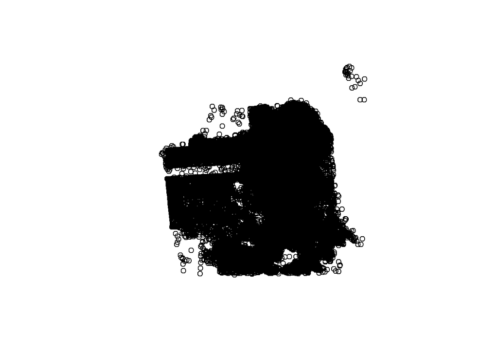

```r
#if you want to create a simple feature dataset then you can use st_as_sf

SP_311<-st_as_sf(data_311, coords = c("Lon","Lat"),crs=4269)

# Show the results
plot(st_geometry(SP_311))
```

## Subsetting Data

It is often necessary to subset data; either restricting a data frame to a set of columns or rows; or in the case of spatial data, creating an extract for a particular set of geographic features. Sub-setting can occur in a number of different ways

```r
#Create a table of frequencies by the categories used within the 311 data
table(data_311$Category)
```

```
##
##         311 External Request            Abandoned Vehicle
##                          179                         5655
##   Blocked Street or SideWalk      Catch Basin Maintenance
##                          941                          161
##                   Color Curb             Damaged Property
##                          146                         1966
##       DPW Volunteer Programs             General Requests
##                            7                         5976
##    Graffiti Private Property     Graffiti Public Property
##                         7436                         9500
##             Illegal Postings    Interdepartmental Request
##                         1137                           90
##           Litter Receptacles                MUNI Feedback
##                         1552                         1928
##                 Noise Report        Rec and Park Requests
##                          626                         1304
## Residential Building Request                 Sewer Issues
##                          295                         2432
##                SFHA Requests             Sidewalk or Curb
##                          693                         1822
##                  Sign Repair Street and Sidewalk Cleaning
##                         1219                        41683
##               Street Defects                 Streetlights
##                         2146                         2155
##       Temporary Sign Request             Tree Maintenance
##                         1045                         1764
##    Unpermitted Cab Complaint
##                            6
```

```r
# Use the subset() function to extract rows from the data which relate to Sewer Issues

sewer_data<-subset(data_311,Category =="Sewer Issues" )
sewer_issues <- subset(data_311,Category == "Sewer Issues")

# Use the square brackets "[]" to perform the same task

data<-data_311[data_311$Category=="Sewer Issues",]

sewer_issues <- data_311[data_311$Category == "Sewer Issues",]

# Extract a list of IDs for the "Sewer Issues"
sewer_issues_IDs <- subset(data_311,Category == "Sewer Issues", select = "CaseID")
```

Subsetting can also be useful for spatial data. In the example above the full extent of San Francisco was plotted, however, for cartographic purposes it may be preferable to remove the “Farallon Islands”. This has a GEOID10 of “06075980401” which can be used to remove this from a plot:

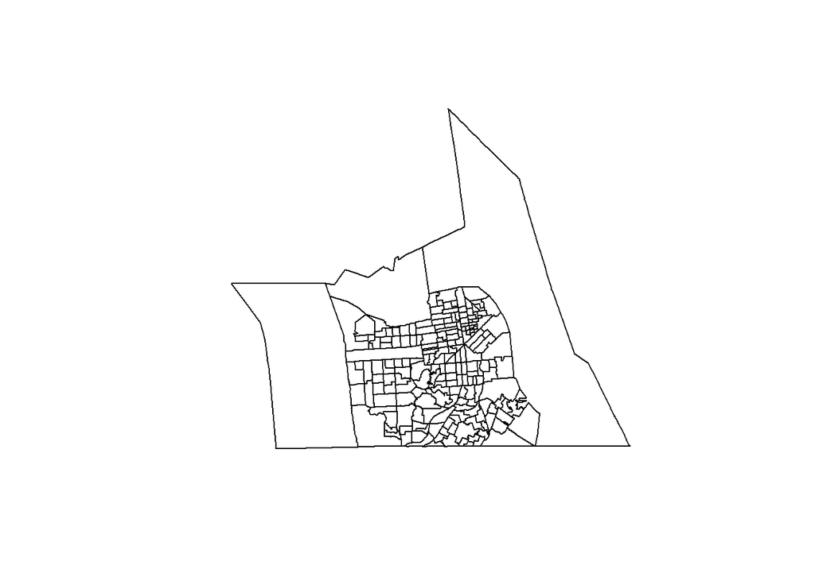

```r
plot(st_geometry(SF[SF$GEOID10 != "06075980401",])) # Removes Farallon Islands from the plot
```

This can also be quite useful if you want to plot only a single feature, for example:

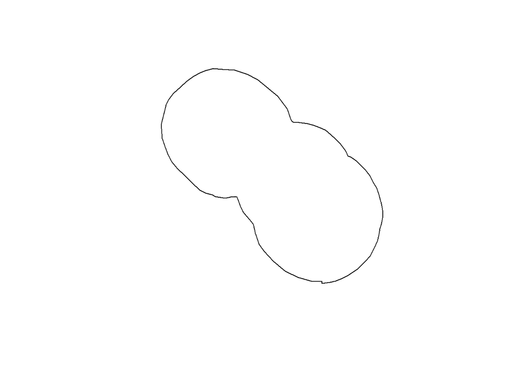

```r
plot(st_geometry(SF[SF$GEOID10 == "06075980401",])) # Only plots Farallon Islands
```

### Clipping Spatial Data

```r
# Read Shapefile using sf package
#San Francisco data
SF2 = st_read("./data/tl_2010_06075_tract10.shp")

#Coast data
coast <- st_read("./data/cb_2015_us_county_500k.shp")
#look at the data
coast

#plot the coast to see what it is.
plot(st_geometry(coast))

#if you want to clip your SF to your coast - you can use st_intersection - this may take a while. Rather than running this whole cell at the same time, run each line separately.
clip<-st_intersection(coast,SF2) # let it run for up to 7 minutes easily :)

plot(st_geometry(clip))

# to save the new shapefile use st_write:

st_write(clip, "data/my_clipped_data.shp") - #you have it saved in your data folder already. If you want just load it in as clip and follow the reminder of the tutorial.


clip2 <- sf:::as_Spatial(clip$geom)

as(clip2,"Spatial")
plot(st_geometry(clip))
plot(st_geometry(clip2))
```

You can also use the same syntax to create a new object - for example:

```r
Clip2 <- clip[clip$GEOID10 != "06075980401",] # Overwrites the SF object
Clip2
plot(st_geometry(Clip2))#check how your clipped data looks like
```

# lets try to filter/clip csv data to our sf

```r
#https://search.r-project.org/CRAN/refmans/sf/html/st_join.html  you can have a look at other join/filter options
Clipped_SP_311 <- st_filter(SP_311, Clip2) # st_filter is the same as st_intersects and was created to be similar to dplyr
Clipped_SP_311

coast_SP_311 <- st_filter(SP_311, coast)
coast_SP_311
plot(st_geometry(coast_SP_311))
```

You can read more cool things about spatial data operations on Geocomputation with R: https://r.geocompx.org/spatial-operations

## Merging Tabular Data

So far we have utilized a single data frame or spatial object; however, it is often the case that in order to generate information, data from multiple sources are required. Where data share a common “key”, these can be used to combine / link tables together. This might for example be an identifier for a zone; and is one of the reasons why most statistical agencies adopt a standard sets of geographic codes to identify areas.

“earnings” included a UID column which relates to a Tract ID. We can now import an additional data table called bachelors - this also includes the same ID.

```r
#Read CSV file - creates a data frame called earnings
bachelors <- read.csv("./data/ACS_14_5YR_S1501_with_ann.csv")
earnings<-read.csv("./data/ACS_14_5YR_S2001_with_ann.csv")
#UID - Tract ID
#Bachelor_Higher - Bachelor degree or higher %
#Bachelor_Higher_m - Bachelor degree or higher % (margin of error)
```

Using the matching ID columns on both datasets we can link them together to create a new object with the merge() function:

```r
#Perform the merge
SF_Tract_ACS <- merge(x=earnings,y=bachelors,by.x="UID",by.y="UID")

SF_Tract_ACS <- merge(earnings,bachelors,by="UID")# An alternative method to the above, but a shortened version as the ID columns are the same on both tables
#You can also use all.x=TRUE (or all.y=TRUE) to keep all the rows from either the x or y table - for more details type ?merge()
#The combined table now looks like
head(SF_Tract_ACS) # shows the top of the table
```

```
##          UID  pop pop_m earnings earnings_m Bachelor_Higher Bachelor_Higher_m
## 1 6075010100 2371   226    49954      15503            44.3              19.5
## 2 6075010200 2975   315    75984      10892            58.8              30.8
## 3 6075010300 2748   324    47586      10549            48.8              13.2
## 4 6075010400 3668   442    48931       6531            35.9              26.1
## 5 6075010500 1562   198   110076       5331            39.2              33.7
## 6 6075010600 2172   374    22074       8666            34.1                23
```

## Removing and Creating Attributes

It is sometimes necessary to remove variables from a tabular object or to create new values. In the following example we will remove some unwanted columns in the SF_clipped object, leaving just the zone id for each polygon.

```r
#Remind yourself what the data look like...
head(Clip2)

Clip2 <- data.frame(Clip2[,"GEOID10"]) #Makes a new version of the @data slot with just the values of the GEOID10 column - this is wrapped with the data.frame() function

#The data frame within the data slot now looks as follows
head(Clip2)
```

These tract ID are supposed to match with those in the “SF_Tract_ACS” object, however, if you are very observant you will notice that there is one issue; the above have a leading zero.

```r
head(SF_Tract_ACS) # show the top of the SF_Tract_ACS object
```

```
##          UID  pop pop_m earnings earnings_m Bachelor_Higher Bachelor_Higher_m
## 1 6075010100 2371   226    49954      15503            44.3              19.5
## 2 6075010200 2975   315    75984      10892            58.8              30.8
## 3 6075010300 2748   324    47586      10549            48.8              13.2
## 4 6075010400 3668   442    48931       6531            35.9              26.1
## 5 6075010500 1562   198   110076       5331            39.2              33.7
## 6 6075010600 2172   374    22074       8666            34.1                23
```

As such, in this instance we will create a new column on the SF_Tract_ACS data frame with a new ID that will match the SF GEOID10 column. We can achieve this using the $ symbol and will call this new variable “GEOID10”.

```r
# Creates a new variable with a leading zero
SF_Tract_ACS$GEOID10 <- paste0("0",SF_Tract_ACS$UID)
head(SF_Tract_ACS)
```

```
##          UID  pop pop_m earnings earnings_m Bachelor_Higher Bachelor_Higher_m
## 1 6075010100 2371   226    49954      15503            44.3              19.5
## 2 6075010200 2975   315    75984      10892            58.8              30.8
## 3 6075010300 2748   324    47586      10549            48.8              13.2
## 4 6075010400 3668   442    48931       6531            35.9              26.1
## 5 6075010500 1562   198   110076       5331            39.2              33.7
## 6 6075010600 2172   374    22074       8666            34.1                23
##       GEOID10
## 1 06075010100
## 2 06075010200
## 3 06075010300
## 4 06075010400
## 5 06075010500
## 6 06075010600
```

```r
str(SF_Tract_ACS)
```

```
## 'data.frame':    197 obs. of  8 variables:
##  $ UID              : num  6.08e+09 6.08e+09 6.08e+09 6.08e+09 6.08e+09 ...
##  $ pop              : int  2371 2975 2748 3668 1562 2172 2716 3173 3517 4030 ...
##  $ pop_m            : int  226 315 324 442 198 374 315 338 258 521 ...
##  $ earnings         : chr  "49954" "75984" "47586" "48931" ...
##  $ earnings_m       : chr  "15503" "10892" "10549" "6531" ...
##  $ Bachelor_Higher  : chr  "44.3" "58.8" "48.8" "35.9" ...
##  $ Bachelor_Higher_m: chr  "19.5" "30.8" "13.2" "26.1" ...
##  $ GEOID10          : chr  "06075010100" "06075010200" "06075010300" "06075010400" ...
```

We can also remove the UID column. A quick way of doing this for a single variable is to use “NULL”:

```r
SF_Tract_ACS$UID <- NULL
head(SF_Tract_ACS)
```

```
##    pop pop_m earnings earnings_m Bachelor_Higher Bachelor_Higher_m     GEOID10
## 1 2371   226    49954      15503            44.3              19.5 06075010100
## 2 2975   315    75984      10892            58.8              30.8 06075010200
## 3 2748   324    47586      10549            48.8              13.2 06075010300
## 4 3668   442    48931       6531            35.9              26.1 06075010400
## 5 1562   198   110076       5331            39.2              33.7 06075010500
## 6 2172   374    22074       8666            34.1                23 06075010600
```

```r
#Replace the "-" and "*" characters (If you are doing this outside of the US / UK and have a non English locale set, try running Sys.setlocale("LC_ALL","English") before using gsub)
SF_Tract_ACS$earnings <- gsub("-",NA,SF_Tract_ACS$earnings,fixed=TRUE) #replace the "-" values with NA
SF_Tract_ACS$earnings_m <- gsub("**",NA,SF_Tract_ACS$earnings_m,fixed=TRUE) #replace the "**" values with NA
SF_Tract_ACS$Bachelor_Higher <- gsub("-",NA,SF_Tract_ACS$Bachelor_Higher,fixed=TRUE) #replace the "-" values with NA
SF_Tract_ACS$Bachelor_Higher_m <- gsub("**",NA,SF_Tract_ACS$Bachelor_Higher_m,fixed=TRUE) #replace the "**" values with NA
```

We will now convert these to numeric values:

```r
str(SF_Tract_ACS)
```

```
## 'data.frame':    197 obs. of  7 variables:
##  $ pop              : int  2371 2975 2748 3668 1562 2172 2716 3173 3517 4030 ...
##  $ pop_m            : int  226 315 324 442 198 374 315 338 258 521 ...
##  $ earnings         : chr  "49954" "75984" "47586" "48931" ...
##  $ earnings_m       : chr  "15503" "10892" "10549" "6531" ...
##  $ Bachelor_Higher  : chr  "44.3" "58.8" "48.8" "35.9" ...
##  $ Bachelor_Higher_m: chr  "19.5" "30.8" "13.2" "26.1" ...
##  $ GEOID10          : chr  "06075010100" "06075010200" "06075010300" "06075010400" ...
```

```r
SF_Tract_ACS$earnings <- as.numeric(SF_Tract_ACS$earnings)
SF_Tract_ACS$earnings_m <- as.numeric(SF_Tract_ACS$earnings_m)
SF_Tract_ACS$Bachelor_Higher <- as.numeric(SF_Tract_ACS$Bachelor_Higher)
SF_Tract_ACS$Bachelor_Higher_m <- as.numeric(SF_Tract_ACS$Bachelor_Higher_m )
```

Now all the variables other than the “GEOID10” are stored as integers or numerics:

```r
str(SF_Tract_ACS)
```

```
## 'data.frame':    197 obs. of  7 variables:
##  $ pop              : int  2371 2975 2748 3668 1562 2172 2716 3173 3517 4030 ...
##  $ pop_m            : int  226 315 324 442 198 374 315 338 258 521 ...
##  $ earnings         : num  49954 75984 47586 48931 110076 ...
##  $ earnings_m       : num  15503 10892 10549 6531 5331 ...
##  $ Bachelor_Higher  : num  44.3 58.8 48.8 35.9 39.2 34.1 21.4 51.3 83 52.6 ...
##  $ Bachelor_Higher_m: num  19.5 30.8 13.2 26.1 33.7 23 13.2 25.8 17 25.3 ...
##  $ GEOID10          : chr  "06075010100" "06075010200" "06075010300" "06075010400" ...
```

## Merging Spatial Data

It is also possible to join tabular data onto a spatial object (e.g. SpatialPolygonsDataFrame) in the same way as with regular data frames. In this example, we will join the newly created SF_Tract_ACS data onto the SF_clipped data frame.

```r
SF_clipped <- merge(Clip2,SF_Tract_ACS, by="GEOID10") # merge, bare in mind that Clip2 here is a spatial data frame not SF
head(SF_clipped)#show the attribute data
names(SF_clipped)
```

### Spatial Joins

Earlier in this practical we clipped 311 phone calls to the extent of San Francisco. You can have a look at the data again by:

```r
plot(st_geometry(coast_SP_311))
```

We will now clean up the associated data frame by removing all of the attributes apart from the category (“data_311.Category”) and then add a sensible column name.

```r
coast_SP_311
coast_SP_311<-as(coast_SP_311,"Spatial")
coast_SP_311@data
coast_SP_311@data <- data.frame(coast_SP_311@data[,"Category",])#subset data
colnames(coast_SP_311@data) <- "Category" #update column names
coast_SP_311<- st_as_sf(coast_SP_311)
```

```r
library(tidyverse)
SF_clipped
# if you want to merge two spatial datasets (SF objects) you need to use st_join and the datasets have to be both sf objects
Clip2<-st_as_sf(Clip2) #this turns spatial data frame to simple feature

SF_clipped2<-st_join(coast_SP_311, Clip2) # this allws you to join your data spatially and will show  you which census tracts each call/crime was made from.
SF_clipped2
```

## buffers

Buffers are polygons representing the area within a given distance of a geometric feature: regardless of whether the input is a point, line or polygon, the output is a polygon. Unlike simplification (which is often used for visualization and reducing file size) buffering tends to be used for geographic data analysis. How many points are within a given distance of this line? Which demographic groups are within travel distance of this new shop? These kinds of questions can be answered and visualized by creating buffers around the geographic entities of interest.

```r
#read in data on some random schools and roads in Leeds


roads <- st_read("./data/Road.shp")

schools <- read.csv("./data/Milton_Keynes_SS_13.csv") # data ocmes in CSV so we need to read it in, eliminate empty rows with no geometry and then  save it as SF.
schools <- subset(schools, Easting != "" | Northing != "")
schools_SDF<-st_as_sf(schools, coords = c("Easting","Northing"),crs=27700)

plot(st_geometry(schools_SDF)) - #plot to have a look at the data.

# create a buffer - remember that buffers have the same unis as coordinates of input layers.

schools_buff_5km = st_buffer(schools_SDF, dist = 5000)
plot(st_geometry(schools_buff_5km))
```

## Learn more about geometric operations:

https://r.geocompx.org/geometry-operations

## Further resources / training

- [R dplyr](https://www.datacamp.com/courses/dplyr-data-manipulation-r-tutorial) - An alternative method of manipulating data in R using the dplyr package

These materials use content from Alex Singleton’s R book.